# Concepts for QA and AM

Quality Assurance and Automation

Peter von Rohr

2018-07-30

# Disclaimer

This document gives an outline of some concepts proposed in the area of quality assurance (QA) and automation (AM). Based these abbreviations, the project is named `QAAM`. In a first step, we are focusing on the QA-part of the project.

# Concept of Quality Assurance (QA) in a Data Analysis (DA)

When looking at quality assurance in a data analysis it appears to be useful to differentiate between the time period

See the diagram below. The horizontal axis corresponds to time and the vertical arrow points to the timepoint when the data analysis is done.

- **before** and
- that **after** the analysis has been done.

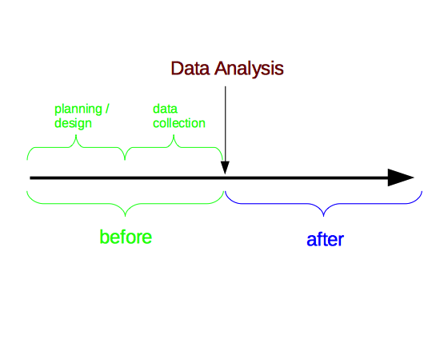

The time period before the analysis has been done, should be used for planning the analysis. Depending on whether the data comes out of a designed experiment or whether the data is collected for some other reason, the work that is done during the planning phase can look different. An experiment should be designed such that the questions of interest can be answered within the budget constraints. When the data is collected for other purposes, the data analysis can still be planned by e.g. comparing different statistical methods based on previously collected or based on simulated data.

In the context of livestock breeding, the data is often collected for other purposes, then for the use in a breeding program. Hence the data that are analyzed in this context are mostly given and the underlying structure of the data cannot be changed. Hence, the planning phase is reduced to comparing different statistical methods for using the given data in an optimal way. In most cases similar data of different countries are available or are described in publications and with results from such previous studies, we can check whether the chosen statistical method is suitable.

Once the data analysis is done, the results of the analysis can be inspected and compared to our expectations from the planning phase or to other results based on the same kind of data. These comparisons might reveal unexpected features of the results. In such a situation, it is very important that we can trust these results. But results of a data analysis can only be trustworthy, when the analysis producing the results fullfills certain quality standards. At this point it is important to note that we must have some measure or some criterion that allows us to quantify the quality of a data analysis.

# Unifying Criterion

The essential criterion of a data analysis that allows us to make any statements about the quality of that analysis is **reproducibility**. It must be emphasized that reproducibility on its own does not guarantee any level of quality, but without reproducibility, it is impossible to assess the quality of a data analysis.

Have a look at the appendix of this document for a definition of reproducibility

## How to ensure reproducibility

Nowadays all data analyses are done using a certain software program. From now on, we call such programs `statistical computing system`. These systems can be used either interactively or in a so-called `batch-mode`. When using such a system interactively, the user enters commands or navigates in GUI-based menus. Data analyses which are done interactively, cannot be made reproducible or are very difficult to be made reproducible.

Examples of such systems are MS Excel, SPSS, SAS, S-Plus, Python, R and many more.

where GUI stands for Graphical User Interface

We shall see later a weaker form of reproducibility which can be postulated for such analyses

Most statistical computing systmes can also be run in a batch-mode. This means that scripts or programs which correspond to sequences of statements that are collected in a file are executed in the statistical computing system. The results produced by the data-analysis program must be collected in a result-file from which it is clear what the name of the program is and when the program was run to produce the given results.

which are called the script or the program

more detailed information such as the version of the statistical computing system, any additional software needed, the operating system and the name of the machine can be helpful and are therefore desirable to be included in a result file

## Weak form of reproducibility

When using a statistical computing system interactively or when performing the data analysis based on a given recipe, we can still obtain a weaker form of reproducibility. This can be achieved by collecting all output that is produced in a protocol document. This protocol lists the steps in the recipe with the associated output. Including the filename of the recipe and the name of the input data and the date when the analysis was performed, we can obtain a weaker form of the above described reproducibility property.

## Ten rules for reproducibility

Sandve et al. (2013) gave ten simple rules that should be followed to reach the goal of reproducibility in computational research.

Sandve, GK, A Nekrutenko, J Taylor, and E Hovig. 2013. “Ten Simple Rules for Reproducible Computational Research.” *PLoS Comput Biol* 9: e1003285. doi:https://doi.org/10.1371/journal.pcbi.1003285.

**Rule 1**: For Every Result, Keep Track of How It Was Produced

- single commands, scripts, programs in executable script forms

**Rule 2**: Avoid Manual Data Manipulation Steps

- inefficient and error-prone not easily reproducible

**Rule 3**: Archive the Exact Versions of All External Programs Used

- it is not always trivial to get hold of a program in anything but the current version
- to ensure future availability, the only viable solution may then be to store a full virtual machine image

**Rule 4**: Version Control All Custom Scripts

- to track evolution of code, use a version control system e.g. Git

**Rule 5**: Record All Intermediate Results, When Possible in Standardized Formats

- if enough storage

**Rule 6**: For Analyses That Include Randomness, Note Underlying Random Seeds

- allows exact results reproducibility

**Rule 7**: Always Store Raw Data behind Plots

- for example R code and the dataframe used as input

**Rule 8**: Generate Hierarchical Analysis Output, Allowing Layers of Increasing Detail to Be Inspected

- if storage allows it, keep track of all intermediate steps that led to the final results

**Rule 9**: Connect Textual Statements to Underlying Results

- within the text description always add links to scripts/data that shaped you logical deductions

**Rule 10**: Provide Public Access to Scripts, Runs, and Results

- for example link to your github account

# How to use reproducibility for quality assurance

Based on the definition of reproducibility, we want to look at the results of a data analysis and be able to determine when the given results were produced, which input data were used and which program has generated those specific results. This requires every program to write the name of the program, the name of the input data file and the time of program execution to the result file. As already mentioned, further information about the analysis such as the machine name, the operating system, the version of the program and any additional software that were used can be very helpful.

Using the information in the resultfile as described in the previous paragraph, we can determine when, based on which input data and by which program a certain result file was generated. Because programs can change over time, it is important to use a version control system for all the programs that are used in a data analysis. Only with a version control system, it is possible to be able to re-create a version of a program at a certain time point.

such as git, svn or cvs

In general input data are too big to be included in a version control system. Furthermore, in most cases input data just grow over time, but they are very rarely changed in a different way. Hence the functionality of a version control system is not really needed for input data. It is sufficient to move input data into an archive where they can be restored in case that a certain analysis has to be reproduced.

Using all this information that characterizes a given data analysis, we are able to reproduce a certain analysis at any given point in time. This is particulary useful if a problem is found in a given data analysis. Being able to reproduce a certain data analysis, it is much easier to search for the causes of the observed problem.

# Techniques And Tools For Reproducible Data Analysis

## Templates

In the previous section, the required information to be included in a data analysis result file was listed. Because each program must write this information into the resultfile and this information is more or less constant, the use of prepared program templates can be very helpful. The template makes sure that the required information is automatically written to the result file. Most programs used for data analyses are written in Bash, Fortran, C/C++, Python or R. For each of these languages templates will be provided that satisfy the described requirement that make any given data analysis reproducible.

# Appendix

## Definition of Reproducibility

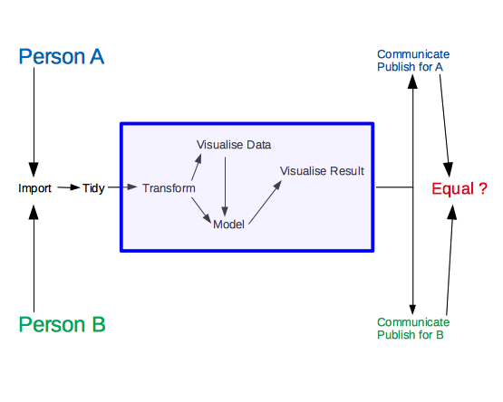

Definition of Reproducibility

A data analysis is *reproducible* if a data analyst which is not the same person as the one who has done the data analysis in the first place, can reproduce the results of the analysis with the same input data and the same programs as the analysis was done by the original data analyst.

This other person that tries to reproduce any given data analysis from the above definition of reproducibility might also be future “you”. In that case reproducibility yields some added benefit for the data analyst her- or himself.

Stevens (2017) gives a distinction between reproducibility and replication.

Stevens, J.R. 2017. “Replicability and Reproducibility in Comparative Psychology.” *Front Psychol* 8: 862.

# Further Resources

This chapter mentions a few resources concerning the concept of reproducibility

## Scientific Research

Fernandes and Vos (2017) is a good resource providing a bird’s eye view of the developments in open scientific research (OSR). OSR is also strongly based on reproducibility of scientific results.

Fernandes, P. L., and R. A. Vos. 2017. *Open Science, Open Data, Open Source*. GitBook. https://pfern.github.io/OSODOS/gitbook/.

## Reproducibility Crisis in Research

The term *reproducibility crisis* or replication crisis has its own [Wikipedia entry](https://en.wikipedia.org/wiki/Replication_crisis). This term summarizes the problem of researchers to reproduce any published scientific results.

## Reproducibility and Software

Boruque, P., and R. E. Fairley, eds. 2004. *Guide to the Software Engineering Body of Knowledge (Swebok)*. IEEE. https://www.computer.org/web/swebok/index.

Often we do not have explicit requirements allowing for a correctness evaluation. In most cases, implicit requirements can be used to get a correctness estimate